# Week 1 Notes Part 4 Professional Data Science Tooling: Reproducible Reporting and Data Management

# 1 Overview

This Note covers the two professional tooling areas that distinguish reproducible, scalable bioinformatics work from ad hoc analysis: how to communicate it and how to store it.

Part 1 covers reproducible reporting with R Markdown and Quarto. The notes you are reading right now are written in R Markdown, a plain-text format that weaves narrative text, R code, and the output that code produces into a single self-contained document. All assignment submissions in this course are R Markdown files that must render correctly to receive full credit. This section explains the format, its syntax, how to knit documents, and introduces Quarto as the modern successor.

# 2 What Is Reproducible Reporting?

A reproducible analysis is one where anyone with access to your code and data can re-run your analysis exactly and arrive at the same results. This is a foundational expectation of modern scientific research; findings that cannot be independently reproduced are not credible, regardless of how sophisticated the underlying methods are.

In practice, reproducibility breaks down in two main ways. First, analysis code and the written interpretation of results exist in separate files: the code in an `.R` script and the writeup in a Word document or PDF. When the analysis changes (you add more samples, fix a bug, try a different parameter), the written document must be manually updated, and it often is not. Second, the analysis depends on packages, data files, or environment settings that are not documented, making it impossible for someone else to reproduce even if they have the code.

R Markdown solves both problems simultaneously. Code and text live in a single file; when the document is rendered (“knitted”), the code runs from scratch in a clean environment, and all figures, tables, and numbers in the text are generated directly from that fresh run. If the underlying data or analysis changes and you re-knit, every result in the document updates automatically. There is no manual copying of numbers.

This matters directly for your career: most research positions, industry data science roles, and regulatory submissions now expect this kind of integrated, self-documenting analysis as a baseline.

# 3 R Markdown: Structure and Syntax

## 3.1 The YAML Header

Every R Markdown file begins with a YAML header (the section between the triple dashes `---`) that specifies document-level settings: title, author, date, and output format.

```yaml
---
title: "My Analysis"
author: "Your Name"
date: "2025-01-15"
output:
  html_document:
    toc: true
    toc_float: true
    code_folding: hide
  pdf_document:
    toc: true
---
```

The `output` field controls what the knitted document looks like. `html_document` produces a webpage that can be opened in any browser; `pdf_document` produces a PDF (requires a LaTeX installation). You can specify both, as shown above; `knitr` will produce both formats when you knit. The course notes use `code_folding: hide` so code chunks are collapsed by default but can be expanded by clicking.

## 3.2 Text Formatting

R Markdown uses Markdown syntax for text formatting:

```markdown
# Level 1 heading
## Level 2 heading
### Level 3 heading

**bold text**
*italic text*
`inline code`

- Bullet point
- Another bullet
  - Indented bullet

1. Numbered list
2. Second item

[Link text](https://www.url.com)
```

## 3.3 Code Chunks

Code chunks are delimited by triple backticks with `{r}` to indicate R code:

````markdown
``` r
library(ALL)
data(ALL)
dim(exprs(ALL))
```

```
## [1] 12625   128
```
````

The most important chunk options are `eval`, which controls whether the code actually runs; `echo`, which controls whether the code itself is shown in the output; `message` and `warning`, which control whether package loading messages and warnings are shown; `fig.height` and `fig.width`, which set the figure dimensions in inches; `cache`, which, when set to TRUE, caches results so that slow chunks do not re-run on every knit; and `results`, which controls how text output is displayed and can be set to `'show'`, `'hide'`, or `'asis'`.

## 3.4 Inline Code

You can embed R expressions directly in text using backtick-r syntax. The expression is evaluated when the document is knitted and the result replaces it in the text:

```markdown
The ALL dataset contains 12625 genes and 128 samples.
```

This is how you should report numerical results: never type a number manually; always have R compute and insert it. This way, if the data changes, every number in the text updates automatically.

## 3.5 A Minimal Working Example

Here is a complete minimal R Markdown document demonstrating all the key elements:

```r
library(ALL); data(ALL)
# This is what a code chunk looks like when it runs:
n.genes   <- nrow(exprs(ALL))
n.samples <- ncol(exprs(ALL))
cat("The ALL dataset contains", n.genes, "genes and", n.samples, "samples.\n")
```

```
## The ALL dataset contains 12625 genes and 128 samples.
```

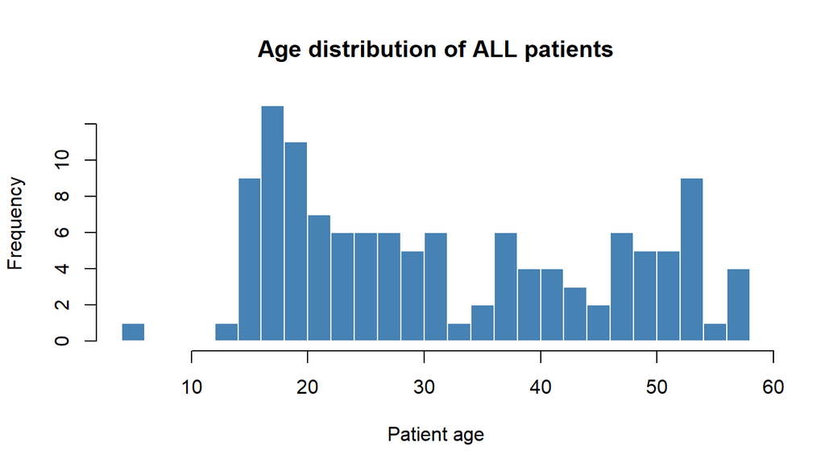

```r
# A figure is generated the same way:
hist(pData(ALL)$age, breaks=20, col="steelblue", border="white",
     xlab="Patient age", main="Age distribution of ALL patients")
```

In a rendered document, the text “The ALL dataset contains 12625 genes and 128 samples” would appear wherever the inline code `12625` and `128` are placed in the prose, not as code output, but as naturally embedded numbers in the narrative.

# 4 Rendering (Knitting) a Document

To render an R Markdown file to HTML or PDF in RStudio, click the Knit button at the top of the editor panel, or use the keyboard shortcut `Ctrl+Shift+K` (Windows/Linux) or `Cmd+Shift+K` (Mac). You can also render programmatically:

```r
rmarkdown::render("my_analysis.Rmd")              # render to default format
rmarkdown::render("my_analysis.Rmd", output_format="html_document")
rmarkdown::render("my_analysis.Rmd", output_format="pdf_document")
```

When you knit, R starts a fresh, clean session, meaning it does not use any objects currently in your RStudio global environment. This is intentional and important: it means the document is genuinely reproducible. A common error when starting with R Markdown is writing code that relies on objects loaded in your global environment but not defined in the document itself. If the document knits successfully, it will work on any computer; if it only runs in your current RStudio session, it is not reproducible.

The knitting errors you are most likely to encounter, and their fixes, are worth knowing in advance. An error reading `object 'x' not found` usually means the variable was defined in your global environment but not in the document itself; the fix is to add the code that creates `x` to a chunk in the document. An error reading `there is no package called 'X'` means the package is not installed in this R installation; the fix is to add `install.packages("X")` or check the spelling. If a package loads but a function is reported missing, the wrong package may have loaded, or the function may live in a different package than expected; check `?function_name` to confirm which package it is actually in. And LaTeX errors when knitting to PDF usually mean LaTeX is not installed or a package is missing; the fix is to use HTML output instead, or install LaTeX support with `tinytex::install_tinytex()`.

# 5 Quarto: The Modern Successor

Quarto is the next-generation version of R Markdown, developed by the same team (Posit, formerly RStudio). It is largely backwards-compatible with R Markdown but adds several important capabilities. It has multi-language support, natively supporting R, Python, Julia, and Observable JavaScript in the same document without extra setup, which is why the course has a separate `6-Rmarkdown_Example_with_Python.Rmd` file; Quarto handles this more cleanly. It offers better output formats, adding first-class support for websites, books, presentations (reveal.js), and dashboards. It uses a unified chunk syntax, with `#|` for chunk options inside the chunk rather than in the `{r ...}` header, making options more readable for long chunks. And it is under active development, with new features being added to Quarto while R Markdown is in maintenance mode.

A Quarto file uses the `.qmd` extension and a nearly identical syntax:

````markdown
---
title: "My Quarto Analysis"
format: html
---

## Analysis


``` r
library(ALL); data(ALL)
hist(pData(ALL)$age)
```

<img src="1-Week1_Notes_Part4_Professional_Tooling_files/figure-html/unnamed-chunk-4-1.png" alt="" width="672" />
````

For this course, R Markdown (`.Rmd`) is used throughout for consistency with existing materials. If you are starting a new project outside the course, Quarto is the recommended choice for new work.

# 6 Best Practices for This Course

Your entire assignment, meaning all questions, all code, all output, and all interpretation, belongs in a single `.Rmd` file that knits cleanly from top to bottom with no errors; do not submit separate R scripts or separate figures. Always test your knit before submitting: knit your document in a fresh R session, restarting R first (`Session > Restart R` in RStudio) and then knitting; if it fails after a restart, it will fail for the grader. Never hardcode numbers in text; use inline code to embed all numerical results, so that if a p-value, sample size, or correlation coefficient appears in your written interpretation, it comes from an inline R expression that computes it, not from you typing it manually. Use `cache=FALSE` for final submissions, since caching (`cache=TRUE`) speeds up development by saving chunk results so they do not re-run on every knit, but cached results can sometimes be stale if you change code without clearing the cache, so setting `cache=FALSE` in all chunks before final submission ensures every result is freshly computed.

Structure your document clearly using `#` headers to organize your analysis. A typical assignment document should have a brief introduction stating what dataset and what question are being addressed, one section per question with the question restated as a heading, code chunks for each question, written interpretation below each chunk, and a brief conclusion.

Finally, push your `.Rmd` and rendered `.html` to GitHub. Assignment submissions should include both the source `.Rmd` file and the rendered `.html` output in your GitHub repository. See the GitHub Notes for the course-wide repository structure.